# Robust Mixed Models and Sensitivity Analysis

mixedFlowR tutorial series

# 1 Purpose

Robust analysis is most useful when it is framed as a sensitivity analysis: would the scientific conclusion change if influential observations or clusters received less leverage under a robust estimator?

The `robustlmm` backend implements robust linear mixed-model estimation (Koller 2016). `mixedFlowR` also supports influence screens, classical-versus-robust comparisons, contamination summaries, and cluster-robust covariance through optional backends.

# 2 1. Learning objectives

You will learn to:

- fit a robust Gaussian mixed model;
- compare classical and robust fixed-effect estimates;
- identify residual and cluster-level sensitivity;
- distinguish influence from data error;
- use cluster-robust covariance as another sensitivity tool;
- construct a transparent contamination analysis;
- report robust results without silently replacing the primary model.

# 3 2. Baseline longitudinal data

```r
library(mixedFlowR)
z <- mixed_data("longitudinal")
```

Fit a classical LMM.

```r
if (requireNamespace("lme4", quietly = TRUE)) {
  classical <- mixed_fit(
    height ~ treatment * time + (1 | subject),
    data = z
  )
}
```

# 4 3. Fit a robust LMM

```r
if (requireNamespace("robustlmm", quietly = TRUE)) {
  robust <- mixed_robust(
    height ~ treatment * time + (1 | subject),
    data = z
  )

  robust
}
```

```
#> $call
#> mixed_robust(formula = height ~ treatment * time + (1 | subject),
#>     data = z)
#>
#> $engine
#> [1] "robustlmm"
#>
#> $model
#> Robust linear mixed model fit by DAStau
#> Formula: height ~ treatment * time + (1 | subject)
#>    Data: ..mf_data
#> Random effects:
#>  Groups   Name        Std.Dev.
#>  subject  (Intercept) 3.310
#>  Residual             1.438
```

[output cut: 209 more lines]

The robust estimator is not a generic replacement for every mixed model. It targets sensitivity to contamination within the supported Gaussian LMM framework.

# 5 4. Compare classical and robust fixed effects

```r
if (exists("classical") && exists("robust")) {
  robust_shift <- mixed_compare_robust(
    classical,
    robust
  )

  robust_shift
}
```

```
#>               term estimate.classical estimate.robust        shift
#> 1      (Intercept)         16.8336323      16.7898873 -0.043744973
#> 2             time          2.0196431       2.0870796  0.067436476
#> 3      treatmentT2          1.4381116       1.4458364  0.007724814
#> 4 treatmentT2:time          0.4899707       0.4131559 -0.076814823
#>   relative_shift
#> 1   -0.002598665
#> 2    0.033390294
#> 3    0.005371498
#> 4   -0.156774308
```

Important columns include the classical estimate, robust estimate, absolute shift, and relative shift where defined.

**Interpretation.** A small shift supports stability under this robustification. A large shift signals sensitivity and should trigger data review and substantive investigation.

# 6 5. Create a deliberately contaminated copy

Add an extreme teaching perturbation to one observation.

```r
z_cont <- z
z_cont$height[1] <- z_cont$height[1] + 30
```

Plot the perturbation.

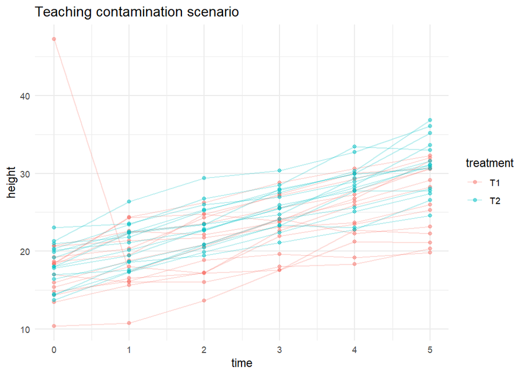

```r
if (requireNamespace("ggplot2", quietly = TRUE)) {
  ggplot2::ggplot(z_cont, ggplot2::aes(time, height, group = subject, colour = treatment)) +
    ggplot2::geom_line(alpha = 0.25) +
    ggplot2::geom_point(alpha = 0.5) +
    ggplot2::theme_minimal(base_size = 11) +
    ggplot2::labs(title = "Teaching contamination scenario")
}
```

# 7 6. Classical fit under contamination

```r
if (requireNamespace("lme4", quietly = TRUE)) {
  classical_cont <- mixed_fit(
    height ~ treatment * time + (1 | subject),
    data = z_cont
  )
}
```

# 8 7. Robust fit under contamination

```r
if (requireNamespace("robustlmm", quietly = TRUE)) {
  robust_cont <- mixed_robust(
    height ~ treatment * time + (1 | subject),
    data = z_cont
  )
}
```

```r
if (exists("classical_cont") && exists("robust_cont")) {
  mixed_compare_robust(
    classical_cont,
    robust_cont
  )
}
```

```
#>               term estimate.classical estimate.robust      shift relative_shift
#> 1      (Intercept)         17.8812513      16.9272389 -0.9540124    -0.05335266
#> 2             time          1.7339288       2.0448294  0.3109006     0.17930414
#> 3      treatmentT2          0.3904925       1.3111260  0.9206334     2.35762095
#> 4 treatmentT2:time          0.7756850       0.4559271 -0.3197579    -0.41222650
```

This is the type of scenario in which classical-versus-robust comparison becomes instructive.

# 9 8. Observation-level robust influence screen

```r
if (exists("classical_cont")) {
  obs_screen <- mixed_robust_influence(
    classical_cont
  )

  head(obs_screen[order(-obs_screen$abs_robust_z), ])
}
```

```
#>     index  residual  robust_z abs_robust_z
#> 1       1 24.717009 16.812256    16.812256
#> 2       2 -6.904267 -4.696212     4.696212
#> 3       3 -5.466513 -3.718266     3.718266
#> 180   180  3.907095  2.657566     2.657566
#> 4       4 -3.607656 -2.453891     2.453891
#> 73     73 -3.471235 -2.361098     2.361098
```

# 10 9. Cluster-level screen

```r
if (exists("classical_cont")) {
  cluster_screen <- mixed_robust_influence(
    classical_cont,
    cluster = "subject"
  )

  cluster_screen
}
```

```
#>    cluster  max_abs_z mean_abs_z
#> 1      S01 16.8122558         NA
#> 2      S02  2.0813418         NA
#> 3      S03  1.9145271         NA
#> 4      S04  1.7089366         NA
#> 5      S05  1.6736472         NA
#> 6      S06  1.3842034         NA
#> 7      S07  1.5567236         NA
#> 8      S08  1.5476161         NA
#> 9      S09  1.3783686         NA
#> 10     S10  2.1480297         NA
#> 11     S11  1.9799375         NA
#> 12     S12  1.5346647         NA
#> 13     S13  2.3610982         NA
#> 14     S14  2.1491920         NA
```

[output cut: 46 more lines]

Cluster aggregation helps identify whether sensitivity is concentrated in one experimental unit rather than one isolated measurement.

# 11 10. Contamination flagging

```r
if (exists("classical_cont")) {
  flags <- mixed_contamination(
    classical_cont,
    cluster   = "subject",
    threshold = 2.5
  )

  flags
}
```

```
#>    cluster flag abs_robust_z
#> 1      S01    1  16.81225577
#> 2      S02    0   2.14919201
#> 3      S03    0   1.97993748
#> 4      S04    0   1.67364720
#> 5      S05    0   1.54761611
#> 6      S06    0   1.43392993
#> 7      S07    0   1.34598374
#> 8      S08    0   1.25663548
#> 9      S09    0   1.16370715
#> 10     S10    0   1.08338959
#> 11     S11    0   0.97244979
#> 12     S12    0   0.94186020
#> 13     S13    0   0.86738520
#> 14     S14    0   0.82682766
```

[output cut: 16 more lines]

Rows are flagged for **review**, never automatically deleted.

# 12 11. What to do after a flag

A defensible sequence is:

1. check the original field sheet, sensor file, or laboratory record;
2. verify units and data entry;
3. identify whether the value is physically plausible;
4. determine whether the observation belongs to a special but valid condition;
5. compare primary and sensitivity analyses;
6. document any exclusion criterion independently of the desired statistical result.

# 13 12. Cluster-robust covariance

`clubSandwich` can provide cluster-robust covariance estimates for supported models.

```r
if (
  exists("classical") &&
  requireNamespace("clubSandwich", quietly = TRUE)
) {
  V_CR2 <- mixed_robust_vcov(
    classical,
    cluster = "subject",
    type    = "CR2"
  )

  V_CR2
}
```

```
#>                  (Intercept) treatmentT2        time treatmentT2:time
#> (Intercept)       0.65650161 -0.65650161 -0.02297941       0.02297941
#> treatmentT2      -0.65650161  1.09912130  0.02297941      -0.02791432
#> time             -0.02297941  0.02297941  0.03534699      -0.03534699
#> treatmentT2:time  0.02297941 -0.02791432 -0.03534699       0.04774617
```

CR2 changes the covariance estimator for fixed effects. It is not the same method as fitting a robust mixed model with `robustlmm`.

# 14 13. Group-deletion influence for lme4

```r
if (
  exists("classical") &&
  requireNamespace("influence.ME", quietly = TRUE)
) {
  infl <- mixed_influence(
    classical,
    group = "subject"
  )

  infl
}
```

```
#> $or.fixed
#>      (Intercept) treatmentT2     time treatmentT2:time
#> [1,]    16.83363    1.438112 2.019643        0.4899707
#>
#> $or.se
#>      (Intercept) treatmentT2       time treatmentT2:time
#> [1,]   0.8255637    1.167523 0.09171587        0.1297058
#>
#> $or.vcov
#>                  (Intercept) treatmentT2         time treatmentT2:time
#> (Intercept)        0.6815554  -0.6815554 -0.021029502      0.021029502
#> treatmentT2       -0.6815554   1.3631108  0.021029502     -0.042059005
#> time              -0.0210295   0.0210295  0.008411801     -0.008411801
#> treatmentT2:time   0.0210295  -0.0420590 -0.008411801      0.016823602
#>
#> $or.test
#>      (Intercept)      treatmentT2             time treatmentT2:time
#>        20.390471         1.231763        22.020650         3.777554
#>
#> $alt.fixed
#>     (Intercept) treatmentT2     time treatmentT2:time
#> S01    16.88879   1.3829570 1.980397        0.5292165
#> S02    16.92279   1.3489540 2.092688        0.4169257
#> S03    16.73654   1.5351999 1.962782        0.5468316
#> S04    16.93969   1.3320587 2.063973        0.4456406
#> S05    16.68489   1.5868532 1.980874        0.5287396
#> S06    17.08961   1.1821291 1.985519        0.5240948
#> S07    16.79783   1.4739102 2.062929        0.4466847
#> S08    16.59039   1.6813498 2.092289        0.4173251
#> S09    16.67992   1.5918233 2.002804        0.5068102
#> S10    17.36529   0.9064541 1.981960        0.5276535
#> S11    17.07416   1.1975793 1.954145        0.5554693
#> S12    16.61334   1.6584040 2.019838        0.4897762
#> S13    16.58147   1.6902713 1.979582        0.5300323
#> S14    16.90996   1.3617800 2.111095        0.3985186
#> S15    16.62979   1.6419501 2.023772        0.4858423
#> S16    16.83363   1.7281031 2.019643        0.4764474
#> S17    16.83363   1.4100335 2.019643        0.4806158
#> S18    16.83363   1.1444447 2.019643        0.5466959
#> S19    16.83363   1.6890868 2.019643        0.4646634
```

[output cut: 277 more lines]

```
#> S19    20.30469   1.4155837 21.86635         3.495467
#> S20    20.69576   1.4224298 21.85772         3.877997
#> S21    20.39417   1.0614771 21.86875         3.568076
#> S22    20.97698   0.9724398 21.84404         3.591730
#> S23    20.02980   1.2229990 21.67422         3.592466
#> S24    20.24286   1.1091510 21.87522         3.525326
#> S25    20.55834   1.3027506 22.27226         4.232003
#> S26    20.06315   1.1523845 21.83574         3.644920
#> S27    20.22419   1.3120881 21.68246         3.740780
#> S28    20.05320   1.1102951 21.84487         3.839101
#> S29    20.03472   1.2412809 21.68709         3.560994
#> S30    20.28507   1.1744185 22.24759         3.335661
#>
#> attr(,"class")
#> [1] "estex"
```

This evaluates sensitivity to deleting whole grouping units and complements residual-based screens.

# 15 14. Robust analysis does not solve model misspecification

If residuals show a strong nonlinear time trend, omitted treatment interaction, or serial dependence, downweighting unusual observations does not correct the mean or covariance model.

Robustness should therefore come **after** the core design and structural modeling decisions.

# 16 15. A three-model sensitivity panel

A useful report can compare:

- classical LMM estimate;
- robust LMM estimate;
- classical estimate with cluster-robust covariance.

These methods address different vulnerabilities and should not be described as interchangeable.

# 17 16. Robust estimate table

```r
if (exists("robust_cont")) {
  mixed_table(
    robust_cont,
    component = "fixed",
    format = "markdown",
    caption = "Robust mixed-model fixed-effect estimates"
  )
}
```

Robust mixed-model fixed-effect estimates

| term | estimate | std.error |
| --- | --- | --- |
| (Intercept) | 16.927 | 0.924 |
| treatmentT2 | 1.311 | 1.307 |
| time | 2.045 | 0.093 |
| treatmentT2:time | 0.456 | 0.132 |

# 18 17. A stricter contamination threshold

```r
if (exists("classical_cont")) {
  mixed_contamination(
    classical_cont,
    cluster = "subject",
    threshold = 3
  )
}
```

```
#>    cluster flag abs_robust_z
#> 1      S01    1  16.81225577
#> 2      S02    0   2.14919201
#> 3      S03    0   1.97993748
#> 4      S04    0   1.67364720
#> 5      S05    0   1.54761611
#> 6      S06    0   1.43392993
#> 7      S07    0   1.34598374
#> 8      S08    0   1.25663548
#> 9      S09    0   1.16370715
#> 10     S10    0   1.08338959
#> 11     S11    0   0.97244979
#> 12     S12    0   0.94186020
#> 13     S13    0   0.86738520
#> 14     S14    0   0.82682766
```

[output cut: 16 more lines]

The threshold is a screening setting, not an objective truth boundary.

# 19 18. Reporting template

A transparent sensitivity paragraph should state:

1. why robust analysis was performed;
2. estimator/backend used;
3. whether influential observations or clusters were identified;
4. how classical and robust estimates differed;
5. whether the primary biological conclusion changed;
6. whether any observation was excluded and why;
7. whether cluster-robust covariance altered uncertainty materially.

# 20 19. Exercises

## 20.1 Exercise 1

Move the contamination from one observation to all measurements of one subject. Compare the change in classical and robust estimates.

## 20.2 Exercise 2

Compare `CR1` and `CR2` covariance estimates when `clubSandwich` is available.

```r
if (
  exists("classical") &&
  requireNamespace("clubSandwich", quietly = TRUE)
) {
  V_CR1 <- mixed_robust_vcov(classical, "subject", "CR1")
  V_CR2 <- mixed_robust_vcov(classical, "subject", "CR2")
}
```

## 20.3 Exercise 3

Use `mixed_contamination()` on the uncontaminated dataset. Explain why a flag can still represent a valid extreme observation rather than an error.

# 21 20. Key take-home messages

- Robust estimation is a sensitivity tool, not a license to ignore model structure.
- Influence and contamination flags trigger review, not automatic deletion.
- Classical and robust estimates should be compared transparently.
- Cluster-robust covariance and robust mixed-model fitting address different inferential vulnerabilities.
- Exclusions require an independently defensible scientific or data-quality reason.

# 22 21. What comes next

Stage 3 begins with `07-bootstrap-inference.Rmd`, which develops interval estimation and parametric-bootstrap comparisons for mixed models.

# 23 References

The robust LMM module builds on the robust scoring-equation framework implemented in `robustlmm` (Koller 2016).

Koller, Manuel. 2016. “Robustlmm: An r Package for Robust Estimation of Linear Mixed-Effects Models.” *Journal of Statistical Software* 75 (6): 1–24. https://doi.org/10.18637/jss.v075.i06.